# Normalisation Tutorial

Database Systems Tutor

30/09/2020

# Required libraries

```r
# Libraries for some functions used
library(stringr)
library(tidyverse)
library(knitr)
library(DT)
library(rpivotTable)
library(openintro)
```

# Normalisation

- Normalisation is a data analysis technique to design a database system.
- It allows the database designer to understand the current data structures in an organisation.
- it aids any future changes and enhancements to the system.
- Normalisation is a technique for producing relational schema with the following properties:
- No Information Redundancy
- No Update Anomalies
- The end result of normalisation is a set of entities, which removes unnecessary redundancy (i.e. duplication of data) and avoids the anomalies which will be discussed next.

# Anomalies

- Anomalies are inconvenient or error-prone situation arising when we process the tables.

3 types of anomalies - Update Anomalies - Delete Anomalies - Insert Anomalies

# The Process of Normalisation

- Process involves applying a series of tests on a relation to determine whether it satisfies or violates the requirements of a given normal form.
- When a test fails, the relation is decomposed into simpler relations that individually meet the normalisation tests.
- The higher the normal form the less vulnerable to update anomalies the relations become.
- Three Normal forms: 1NF, 2NF and 3NF were initially proposed by Codd.
- All these normal forms are based on the functional dependencies among the attributes of a relation.

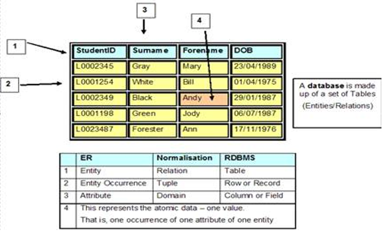

```r
include_graphics("C:/Users/Student/terminology.png")
```

# Normlisation by Example

- Normalisation is a bottom-up technique for database design, normally based on an existing system (which may be paper-based).

Bottom-up - Step 1: Identity data elements - Step 2: Group them into datasets

Top-down - Step 1: Identity datasets - Step 2: Define data elements

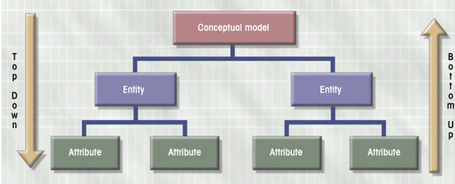

```r
include_graphics("C:/Users/Student/design.png")
```

# Example

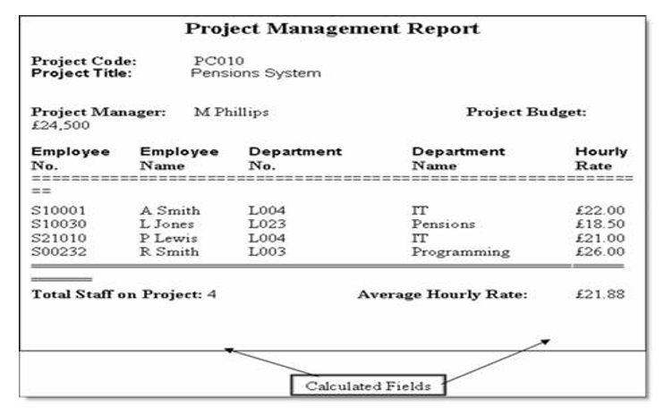

```r
include_graphics("C:/Users/Student/example1.png")
```

## UNF: Unnormalised table creation - Dataframe to demonstrate normalization - For more information check slides provided in the notes

```r
# Creating the attributes with sample values
Project_Code <- c("PC010","PC010","PC010","PC045","PC045","PC045","PC045","PC064","PC064","PC064")
Project_Title <- c("Pensions System","Pensions System","Pensions System","Salaries System",
                   "Salaries System","Salaries System","Salaries System","HR System",
                   "HR System","HR System")
Project_Manager <- c("M Phillips","M Phillips","M Phillips","H Martin","H Martin","H Martin",
                     "H Martin","K lewis","K lewis","K lewis")
Project_Budget <- c(24500,24500,24500,17400,17400,17400,17400,12250,12250,12250)
Employee_No <- c("S10001","S10030","S21010","S10010","S10001","S31002","S13210","S31002",
                 "S21010","S10034")
Employee_Name <- c("A Smith","L Jones","P Lewis","B Jones","A Smith","T Gilbert","W Richards",
                   "T Gilbert","P Lewis","B James")
Department_No <- c("L004","L023","L004","L004","L004","L028","L008","L028","L004","L009")
Department_Name <- c("IT","Pesnions","IT","IT","IT","Database","Salary","Database","IT","HR")
Hourly_Rate <- c(22.00,18.50,21.00,21.75,18.00,25.50,17.00,23.25,17.50,16.50)

# Placing the attributes into a dataframe
df <- data.frame(Project_Code,Project_Title,Project_Manager,Project_Budget,Employee_No,Employee_Name,
                 Department_No, Department_Name, Hourly_Rate)
```

# Data Table

```r
datatable(df, # When placed in UNF possible Key: Project code
          caption = "Project Management Report Sample data",
          rownames = T,
          filter = "top",
          options = list(pageLength = 10))
```

|  | Project_Code | Project_Title | Project_Manager | Project_Budget | Employee_No | Employee_Name | Department_No | Department_Name | Hourly_Rate |
| --- | --- | --- | --- | --- | --- | --- | --- | --- | --- |
| 1 | PC010 | Pensions System | M Phillips | 24500 | S10001 | A Smith | L004 | IT | 22 |
| 2 | PC010 | Pensions System | M Phillips | 24500 | S10030 | L Jones | L023 | Pesnions | 18.5 |
| 3 | PC010 | Pensions System | M Phillips | 24500 | S21010 | P Lewis | L004 | IT | 21 |
| 4 | PC045 | Salaries System | H Martin | 17400 | S10010 | B Jones | L004 | IT | 21.75 |
| 5 | PC045 | Salaries System | H Martin | 17400 | S10001 | A Smith | L004 | IT | 18 |
| 6 | PC045 | Salaries System | H Martin | 17400 | S31002 | T Gilbert | L028 | Database | 25.5 |
| 7 | PC045 | Salaries System | H Martin | 17400 | S13210 | W Richards | L008 | Salary | 17 |
| 8 | PC064 | HR System | K lewis | 12250 | S31002 | T Gilbert | L028 | Database | 23.25 |
| 9 | PC064 | HR System | K lewis | 12250 | S21010 | P Lewis | L004 | IT | 17.5 |
| 10 | PC064 | HR System | K lewis | 12250 | S10034 | B James | L009 | HR | 16.5 |

# UNF Table (Unnormalised Form UNF)

```r
knitr::kable(df,
             caption = "UNF Table")
```

UNF Table

| Project_Code | Project_Title | Project_Manager | Project_Budget | Employee_No | Employee_Name | Department_No | Department_Name | Hourly_Rate |
| --- | --- | --- | --- | --- | --- | --- | --- | --- |
| PC010 | Pensions System | M Phillips | 24500 | S10001 | A Smith | L004 | IT | 22.00 |
| PC010 | Pensions System | M Phillips | 24500 | S10030 | L Jones | L023 | Pesnions | 18.50 |
| PC010 | Pensions System | M Phillips | 24500 | S21010 | P Lewis | L004 | IT | 21.00 |
| PC045 | Salaries System | H Martin | 17400 | S10010 | B Jones | L004 | IT | 21.75 |
| PC045 | Salaries System | H Martin | 17400 | S10001 | A Smith | L004 | IT | 18.00 |
| PC045 | Salaries System | H Martin | 17400 | S31002 | T Gilbert | L028 | Database | 25.50 |
| PC045 | Salaries System | H Martin | 17400 | S13210 | W Richards | L008 | Salary | 17.00 |
| PC064 | HR System | K lewis | 12250 | S31002 | T Gilbert | L028 | Database | 23.25 |
| PC064 | HR System | K lewis | 12250 | S21010 | P Lewis | L004 | IT | 17.50 |
| PC064 | HR System | K lewis | 12250 | S10034 | B James | L009 | HR | 16.50 |

# 1NF Tables: Repeating Attributes Removed

```r
# selects column 1 to 4 values that are not duplicates
df1_1 <- unique(df[, 1:4])
knitr::kable(df1_1,
             caption = "1NF Table 1")
```

1NF Table 1

|  | Project_Code | Project_Title | Project_Manager | Project_Budget |
| --- | --- | --- | --- | --- |
| 1 | PC010 | Pensions System | M Phillips | 24500 |
| 4 | PC045 | Salaries System | H Martin | 17400 |
| 8 | PC064 | HR System | K lewis | 12250 |

```r
# To view entire table run df1_1 on the rmarkdown file
```

```r
# The follwing code excludes 2nd, 3rd and 4th column/attributes
df1_2 <- df[c(-2,-3,-4)] # Compound Key formed for Project Code Employee No
knitr::kable(df1_2,
             caption = "1NF Table 2")
```

1NF Table 2

| Project_Code | Employee_No | Employee_Name | Department_No | Department_Name | Hourly_Rate |
| --- | --- | --- | --- | --- | --- |
| PC010 | S10001 | A Smith | L004 | IT | 22.00 |
| PC010 | S10030 | L Jones | L023 | Pesnions | 18.50 |
| PC010 | S21010 | P Lewis | L004 | IT | 21.00 |
| PC045 | S10010 | B Jones | L004 | IT | 21.75 |
| PC045 | S10001 | A Smith | L004 | IT | 18.00 |
| PC045 | S31002 | T Gilbert | L028 | Database | 25.50 |
| PC045 | S13210 | W Richards | L008 | Salary | 17.00 |
| PC064 | S31002 | T Gilbert | L028 | Database | 23.25 |
| PC064 | S21010 | P Lewis | L004 | IT | 17.50 |
| PC064 | S10034 | B James | L009 | HR | 16.50 |

```r
# To view entire table run df1_2 on the rmarkdown file
```

# 1NF to 2NF Tables

```r
# Project attribute table remains unchanged hence using the same df1_1 table
df2_1 <- df1_1
knitr::kable(df2_1,
             caption = "2NF Table 1")
```

2NF Table 1

|  | Project_Code | Project_Title | Project_Manager | Project_Budget |
| --- | --- | --- | --- | --- |
| 1 | PC010 | Pensions System | M Phillips | 24500 |
| 4 | PC045 | Salaries System | H Martin | 17400 |
| 8 | PC064 | HR System | K lewis | 12250 |

```r
# To view entire table run df2_1 on the rmarkdown file
```

```r
# Above code filters out the the 1st, 2nd and 6th column
df2_2 <- df1_2[c(1,2,6)] # Compound key Project Code and Employee No (underlined)
knitr::kable(df2_2,
             caption = "2NF Table 2")
```

2NF Table 2

| Project_Code | Employee_No | Hourly_Rate |
| --- | --- | --- |
| PC010 | S10001 | 22.00 |
| PC010 | S10030 | 18.50 |
| PC010 | S21010 | 21.00 |
| PC045 | S10010 | 21.75 |
| PC045 | S10001 | 18.00 |
| PC045 | S31002 | 25.50 |
| PC045 | S13210 | 17.00 |
| PC064 | S31002 | 23.25 |
| PC064 | S21010 | 17.50 |
| PC064 | S10034 | 16.50 |

```r
# To view entire table run df2_2 on the rmarkdown file
```

```r
df2_3 <- unique(df1_2[c(-1, -6)]) # Employee_No (underlined) attribute is a key in this table
knitr::kable(df2_3,
             caption = "2NF Table 3")
```

2NF Table 3

|  | Employee_No | Employee_Name | Department_No | Department_Name |
| --- | --- | --- | --- | --- |
| 1 | S10001 | A Smith | L004 | IT |
| 2 | S10030 | L Jones | L023 | Pesnions |
| 3 | S21010 | P Lewis | L004 | IT |
| 4 | S10010 | B Jones | L004 | IT |
| 6 | S31002 | T Gilbert | L028 | Database |
| 7 | S13210 | W Richards | L008 | Salary |
| 10 | S10034 | B James | L009 | HR |

```r
# To view entire table run df2_3 on the rmarkdown file
```

# 3NF Tables: Non-key Dependencies Removed

```r
df3_1 <- df2_1 # Project attribute table remains unchanged hence using the same df2_1 table
#df3_1  # Primary key Project code
knitr::kable(df3_1,
             caption = "3NF Table 1")
```

3NF Table 1

|  | Project_Code | Project_Title | Project_Manager | Project_Budget |
| --- | --- | --- | --- | --- |
| 1 | PC010 | Pensions System | M Phillips | 24500 |
| 4 | PC045 | Salaries System | H Martin | 17400 |
| 8 | PC064 | HR System | K lewis | 12250 |

```r
# To view entire table run df3_1 on the rmarkdown file
```

```r
df3_2 <- df2_2 # Foreign key Project* code and Employee_No*
# NB: Ignore tables with zero or only one non-key attribute (these go straight to 3NF with no conversion).
knitr::kable(df3_2,
             caption = "3NF Table 2")
```

3NF Table 2

| Project_Code | Employee_No | Hourly_Rate |
| --- | --- | --- |
| PC010 | S10001 | 22.00 |
| PC010 | S10030 | 18.50 |
| PC010 | S21010 | 21.00 |
| PC045 | S10010 | 21.75 |
| PC045 | S10001 | 18.00 |
| PC045 | S31002 | 25.50 |
| PC045 | S13210 | 17.00 |
| PC064 | S31002 | 23.25 |
| PC064 | S21010 | 17.50 |
| PC064 | S10034 | 16.50 |

```r
# To view entire table run df3_2 on the rmarkdown file
```

```r
df3_3 <- df2_3[c(-4)] #Primary Key Employee_No and Foreign key Department No*
knitr::kable(df3_3,
             caption = "3NF Table 3")
```

3NF Table 3

|  | Employee_No | Employee_Name | Department_No |
| --- | --- | --- | --- |
| 1 | S10001 | A Smith | L004 |
| 2 | S10030 | L Jones | L023 |
| 3 | S21010 | P Lewis | L004 |
| 4 | S10010 | B Jones | L004 |
| 6 | S31002 | T Gilbert | L028 |
| 7 | S13210 | W Richards | L008 |
| 10 | S10034 | B James | L009 |

```r
# To view entire table run df3_3 on the rmarkdown file
```

```r
df3_4 <- unique(df2_3[c(3,4)]) #Primary Key Department No (underlined)
#df3_4
knitr::kable(df3_4,
             caption = "3NF Table 4")
```

3NF Table 4

|  | Department_No | Department_Name |
| --- | --- | --- |
| 1 | L004 | IT |
| 2 | L023 | Pesnions |
| 6 | L028 | Database |
| 7 | L008 | Salary |
| 10 | L009 | HR |

```r
# To view entire table run df3_4 on the rmarkdown file
```

# Relation schemas

- Project (code(underlined), title, manager, budget)
- Hourly_Rate (Project code(FK), employee_No(FK), Hourly Rate)
- Employee(Employee_No(underlined), Employee_Name, Department_No(FK))
- Department(Department_No(underlined), Department_Name)
- asterisks(*) indicates foreign key
- underlined indicates a Key either primary, simple or compound
- Used FK in place of (*) due to syntax